# Author

- Name: Hsieh, Wang-Lin 謝旺霖
- Student ID: 41341126S
- Email: a0976802947@gmail.com
- Group Member: no other members

# Dataset

[Taiwan Air Quality Index Data 2016~2024](https://www.kaggle.com/datasets/taweilo/taiwan-air-quality-data-20162024)

The Air Quality Index (AQI) is a standardized indicator used to measure air quality in relation to various pollutants. The AQI levels range from 0 to 500, with higher values indicating worse air quality and potential health risks. The pollutants tracked in this dataset include: PM2.5, PM10, SO2, NOx, CO and O3.

# Intoduction

We're curious about which county has the highest average AQI and which one has recorded the highest AQI ever. To find out, we'll create two charts: one showing the average AQI and another showing the highest AQI across the counties.

[The Github page of this project](https://yanggeng1230.github.io/DSCP-Final-Project/)

## Loading Data

```python
import pandas as pd
import numpy as np
import matplotlib.pyplot as plt
import seaborn as sns
```

```python
file = "./air_quality.csv"
data = pd.read_csv(file, low_memory=False)
data.head()
```

|  | date | sitename | county | aqi | pollutant | status | so2 | co | o3 | o3_8hr | ... | windspeed | winddirec | unit | co_8hr | pm2.5_avg | pm10_avg | so2_avg | longitude | latitude | siteid |
| --- | --- | --- | --- | --- | --- | --- | --- | --- | --- | --- | --- | --- | --- | --- | --- | --- | --- | --- | --- | --- | --- |
| 0 | 2024-08-31 23:00 | Hukou | Hsinchu County | 62.0 | PM2.5 | Moderate | 0.9 | 0.17 | 35.0 | 40.2 | ... | 2.3 | 225 | NaN | 0.2 | 20.1 | 26.0 | 1.0 | 121.038869 | 24.900097 | 22.0 |
| 1 | 2024-08-31 23:00 | Zhongming | Taichung City | 50.0 | NaN | Good | 1.6 | 0.32 | 27.9 | 35.1 | ... | 1.1 | 184 | NaN | 0.2 | 15.3 | 23.0 | 1.0 | 120.641092 | 24.151958 | 31.0 |
| 2 | 2024-08-31 23:00 | Zhudong | Hsinchu County | 45.0 | NaN | Good | 0.4 | 0.17 | 25.1 | 40.6 | ... | 0.4 | 210 | NaN | 0.2 | 13.8 | 24.0 | 0.0 | 121.088955 | 24.740914 | 23.0 |
| 3 | 2024-08-31 23:00 | Hsinchu | Hsinchu City | 42.0 | NaN | Good | 0.8 | 0.2 | 30.0 | 35.9 | ... | 1.9 | 239 | NaN | 0.2 | 13.0 | 26.0 | 1.0 | 120.972368 | 24.805636 | 24.0 |
| 4 | 2024-08-31 23:00 | Toufen | Miaoli County | 50.0 | NaN | Good | 1.0 | 0.16 | 33.5 | 35.9 | ... | 1.8 | 259 | NaN | 0.1 | 15.3 | 28.0 | 1.0 | 120.898693 | 24.696907 | 25.0 |

5 rows × 25 columns

```python
data.info()
```

```
<class 'pandas.core.frame.DataFrame'>
RangeIndex: 5882208 entries, 0 to 5882207
Data columns (total 25 columns):
 #   Column     Dtype
---  ------     -----
 0   date       object
 1   sitename   object
 2   county     object
 3   aqi        float64
 4   pollutant  object
 5   status     object
 6   so2        object
 7   co         object
 8   o3         object
 9   o3_8hr     object
```

[output cut: 17 more lines]

## Cutting Necessary Columns

### Pseudocode

1. Select the `'date'`, `'sitename'`, `'county'`, and `'aqi'` columns, and store them in a new variable called **subset**.
2. Display basic description of **subset**.

```python
subset = data.iloc[:, 0:4]
subset.head()
```

|  | date | sitename | county | aqi |
| --- | --- | --- | --- | --- |
| 0 | 2024-08-31 23:00 | Hukou | Hsinchu County | 62.0 |
| 1 | 2024-08-31 23:00 | Zhongming | Taichung City | 50.0 |
| 2 | 2024-08-31 23:00 | Zhudong | Hsinchu County | 45.0 |
| 3 | 2024-08-31 23:00 | Hsinchu | Hsinchu City | 42.0 |
| 4 | 2024-08-31 23:00 | Toufen | Miaoli County | 50.0 |

```python
print(subset.describe(), end='\n===================\n')

print(subset.isnull().sum())
```

```
                aqi
count  5.839188e+06
mean   5.419277e+01
std    2.985864e+01
min   -1.000000e+00
25%    3.200000e+01
50%    4.600000e+01
75%    7.000000e+01
max    5.000000e+02
===================
date            0
sitename        0
county          0
aqi         43020
dtype: int64
```

## Average AQI by County

### Pseudocode

1. Calculate the average AQI for each county, sort the results, and store them in a new variable called **county_mean**.
2. Use **county_mean** to create a bar chart with the average AQI on the x-axis and the counties on the y-axis.

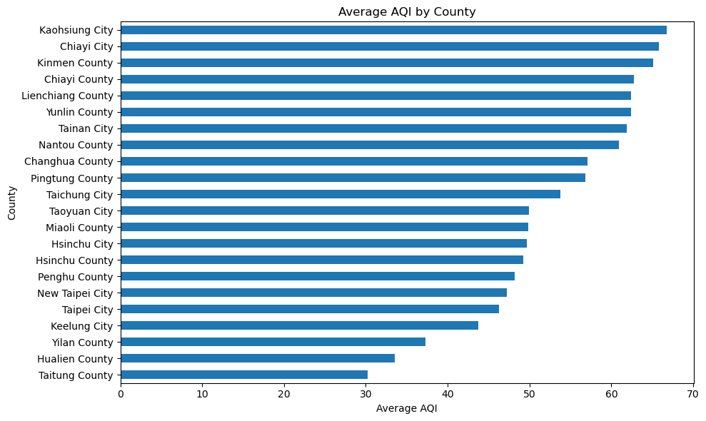

```
county
Taitung County       30.254925
Hualien County       33.505000
Yilan County         37.321559
Keelung City         43.697367
Taipei City          46.308694
New Taipei City      47.223426
Penghu County        48.154552
Hsinchu County       49.242568
Hsinchu City         49.628135
Miaoli County        49.802628
Taoyuan City         49.931332
Taichung City        53.801838
Pingtung County      56.859208
Changhua County      57.052537
Nantou County        60.957194
Tainan City          61.855319
Yunlin County        62.428586
Lienchiang County    62.447049
Chiayi County        62.794208
Kinmen County        65.085950
Chiayi City          65.775401
Kaohsiung City       66.743830
Name: aqi, dtype: float64
```

```python
county_mean = subset.groupby('county')['aqi'].mean().sort_values()

plt.figure(figsize=(10, 6))
county_mean.plot(kind='barh')
plt.title('Average AQI by County')
plt.xlabel('Average AQI')
plt.ylabel('County')
plt.tight_layout()
plt.show()

print(county_mean)
```

## Highest AQI by County

We found that both Changhua and Yunlin counties have recorded the highest AQI ever (500.0), which suggests that people living in these areas should pay attention to air quality on certain days.

### Pseudocode

1. Find the highest AQI for each county, sort the results, and store them in a new variable called **county_max**.
2. Use **county_max** to create a bar chart with the highest AQI on the x-axis and the counties on the y-axis.

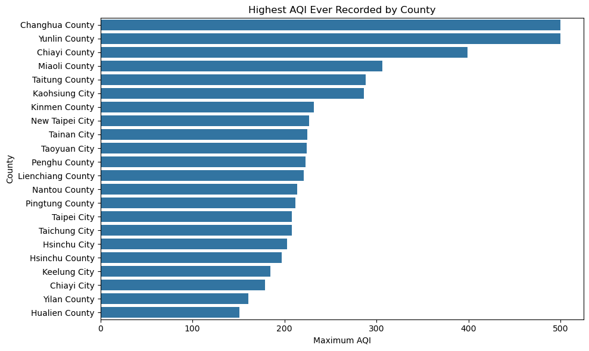

```
                     date             sitename             county    aqi
4127729  2019-07-02 18:00   Changhua (Dacheng)    Changhua County  500.0
4975024  2018-04-07 11:00                Taixi      Yunlin County  500.0
4601342  2018-10-27 18:00                 Puzi      Chiayi County  399.0
4791147  2018-07-16 06:00               Toufen      Miaoli County  306.0
4853703  2018-06-12 06:00             Guanshan     Taitung County  288.0
5486824  2017-07-01 18:00              Meinong     Kaohsiung City  286.0
1492448  2022-08-27 21:00               Kinmen      Kinmen County  232.0
1793328  2022-04-02 17:00  New Taipei (Shulin)    New Taipei City  227.0
1184468  2023-01-24 12:00      Tainan (Xuejia)        Tainan City  225.0
1830329  2022-03-15 16:00    Taoyuan (Yangmei)       Taoyuan City  224.0
5152108  2018-01-01 03:00               Magong      Penghu County  223.0
5258405  2017-11-04 00:00                Matsu  Lienchiang County  221.0
4098145  2019-07-17 20:00                 Puli      Nantou County  214.0
5837047  2016-12-20 21:00             Chaozhou    Pingtung County  212.0
5538355  2017-06-03 08:00               Guting        Taipei City  208.0
3274719  2020-09-07 20:00                Shalu      Taichung City  208.0
3348606  2020-07-31 20:00              Hsinchu       Hsinchu City  203.0
4946625  2018-04-22 19:00                Hukou     Hsinchu County  197.0
4851948  2018-06-13 05:00              Keelung       Keelung City  185.0
4640023  2018-10-06 18:00               Chiayi        Chiayi City  179.0
5344384  2017-09-17 21:00                Yilan       Yilan County  161.0
2888821  2021-02-12 03:00              Hualien     Hualien County  151.0
```

```python
county_max = subset.loc[subset.groupby('county')['aqi'].idxmax()].copy()

county_max = county_max.sort_values(by='aqi', ascending=False)

plt.figure(figsize=(10, 6))
sns.barplot(x='aqi', y='county', data=county_max)

plt.title('Highest AQI Ever Recorded by County')
plt.xlabel('Maximum AQI')
plt.ylabel('County')
plt.tight_layout()
plt.show()

print(county_max)
```